# Generative Art with Python

## Assignment 03 - 215533M

Here I am trying to create a generative art piece for a night sky that contains a moon and stars. For that I use python libraries such as pygame, numpy, random and matplotlib.

```python
# import python libraries
import pygame
import numpy as np
import random
import matplotlib.pyplot as plt
```

```
pygame 2.3.0 (SDL 2.24.2, Python 3.9.12)
Hello from the pygame community. https://www.pygame.org/contribute.html
```

```python
# Initialize pygame library
pygame.init()

# Set the size of the screen
width, height = 800, 800
screen = pygame.display.set_mode((width, height))
```

Here pygame library is initialized and set the width and height of the screen which should be displayed to 800 pixels each.

```python
# Define variables and constants

# Number of crosses to be included
num_cross = 200

# Size of each cross
cross_size = 10

# List of colors to use for crosses
cross_colors = [(255, 255, 255),(255, 215, 0),(255, 165, 0),(218, 112, 214),(255, 235, 59)]

# Radius of the moon
moon_radius = 100

# Color of the moon
moon_color = (255, 235, 59)

# Number of stars
num_stars = 20

# Color of the stars
star_color = (255, 255, 255)

# Size of each star
star_size = 3

# background color of the art
background_color = (7, 11, 52)
```

The variables and constants are initialized.

```python
# Generate random positions for crosses
cross_pos = np.random.randint(0, width, size=(num_cross, 2))
```

Here I generate random positions for crosses using 'np.random.randint()' function in numpy library. It generates random integers within a specified range. Here it generates random x and y coordinates and form '0' to 'width' which is the width of the screen.

This function returns a 2D array num_cross rows and 2 columns. Each row contains x, y coordinates for a single cross.

```python
# Create an empty image
sky_image = np.full((width, height, 3), background_color, dtype=np.uint8)
```

This creates an empty image with specified dimensions 'width' and 'height' and fills it with background color of 'Cetacean Blue'.

```python
# Draw crosses on the empty image
for i in range(num_cross):
    x, y = cross_pos[i]
    color = random.choice(cross_colors)

    # Draw the horizontal line of the cross
    sky_image[x-cross_size : x+cross_size , y, :] = color

    # Draw the vertical line of the cross
    sky_image[x, y-cross_size : y+cross_size , :] = color
```

Here draws the crosses at each position by iterating the coordinates by selecting a random color from 'cross_colors' list. The size of each cross is 'cross_size'.

```python
# Draw the stars
for i in range(1, num_cross//2):
    x, y = cross_pos[i]
    sky_image[x-star_size : x+star_size, y-star_size : y+star_size, :] = star_color
```

Using a foor loop I draw stars on the generated sky_image. In each iteration it gets x,y coordinate pair from the 'cross_pos' list. It sets the pixels within a square region at the coordinate position to star_color value using size of the star.

```python
# Draw the moon
moon_x, moon_y = width - moon_radius - 500, moon_radius + 200
for x in range(width):
    for y in range(height):
        if np.sqrt((x-moon_x)**2 + (y-moon_y)**2) <= moon_radius:
            sky_image[x, y, :] = moon_color
```

Here I draw a yellow circle on the image as the moon. Location of the moon is determined using moon radius and the width of the image.

If statement checks if the distance between the current pixel and the center of the moon is less than or equal to the radius of the moon. (np.sqrt((x-moon_x) **2 + (y-moon_y)** 2)).

If this condition is true, the pixel's color is set to the moon color (image[x, y, :] = moon_color).

```python
# Draw a shadow circle to hide a part of the moon
moon_x, moon_y = width - moon_radius - 550, moon_radius + 250
for x in range(width):
    for y in range(height):
        if np.sqrt((x-moon_x)**2 + (y-moon_y)**2) <= moon_radius:
            sky_image[x, y, :] = background_color
```

Previously I drew a full moon. But I need a crescent moon. Therefore I draw another circle in background color which is overlapping the previous moon. It hides a part of the moon.

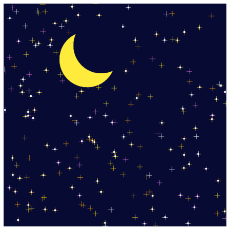

```python
# Display the image using matplotlib
plt.figure(figsize=(8, 8))
plt.imshow(sky_image)
plt.axis("off")

plt.show()
```

#### So here is my generative art!! A night sky with stars, crosses and a moon..

Here I use Matplotlib library to display my generated image.

I used plt.figure() function to increase the plot size than the default size. Then I used imshow() function to display the generated image 'sky_image'.

The axis() function with the argument "off" is used to turn off the axis labels and ticks. Finally, the show() function is called to display the image.

```python
# Quit pygame
pygame.quit()
```

pygame.quit() is called to properly shut down the Pygame module and release all of its resources. It should be called at the end of any Pygame program to release all system resources held by Pygame.

#### It's the end of the Art!!